# MLGWAS: Machine Learning for Genome-Wide Association Studies

Olivier M. F. Martin

2016-12-10

## Table of Contents

1. Introduction
2. Installation and Citation
3. Importing Clinical and Genomics Data into MDT Objects
4. Annotating MDT Objects
5. Manipulating and Plotting MDT Objects
6. MLGWAS Objects - Training Classifiers
7. Session Info

## 1. Introduction

1. Import VCF file and clinical data into an R S4 object named `MDT` and based on the `data.table` package;
2. Annotate variants using Bioconductor annotations packages;
3. Estimate different statistics for variants such as p-values for Hardy-Weinberg equilibrium tests or association tests as well as Minor Allele Frequency (MAF).
4. Filter out variants or samples;
5. Use this data to train classifiers using `caret` package, and organize results (classifiers, predictions, errors, feature importance) in one R S4 object named `MLGWAS` and based on the `data.table` package;
6. Plot and analyze genomics and classification data using the `ggplot2` package.

## 2. Installation and Citation

To install the `MachineLearningGWAS`, install [R](https://www.r-project.org/) and [RStudio](https://www.rstudio.com/), and then run the following code in the R console:

```r
# install.packages("devtools")
devtools::install_github("olivmrtn/MachineLearningGWAS")
```

To load package to namespace, run the following code:

```r
library(MachineLearningGWAS)
```

```r
citation("MachineLearningGWAS")
```

[output not shown]

## 3. Creating MDT Objects - Importing Clinical and Genomics Data

Throughout this tutorial, we will use simulated data. Genomics data is the VCF file `snps.vcf` file and clinical data is tab-delimited file `clinical.txt`. These can be retrieved using the following commands.

```r
genotype_file <- system.file("extdata", "snps.vcf",
                             package = "MachineLearningGWAS")
clinical_file <- system.file("extdata", "clinical.txt",
                             package = "MachineLearningGWAS")
```

Briefly, the genomics data is composed of 200 samples and 1000 SNPs, out of which only 5 of them are truly associated with the response. These are indicated in the `AS` field with a `1`. Genotypes are in the `GT` field. The data is also comprised of dbSNP rs# identifier, and quality `QUAL` and sequencing depth `DP`.

Clinical data specifies the disease status of the patient (`RESPONSE`), as well as age (`AGE`), sex (`SEX`) and patient identifier (`SampleID`).

Currently, it is only possible to import genomics data as a `list` of `VCF` objects of the `VariantAnnotation` package. This can be done using the `readVcf` function. Alternatively, if your data is divided into more than one VCF files, you can use the `readVcfDir` function in this package.

```r
vcf <- VariantAnnotation::readVcf(genotype_file)
mdt <- vcfsToMDT(list(vcf))
```

Clinical data can be imported using the `importPhenotype` function. The `response_type` argument specifies if the `RESPONSE` should be treated as a categorical or continuous variable and `sep` specifies the file separator.

```r
mdt <- importPhenotype(mdt, clinical_file, response_type = "factor", sep = "\t")
```

Printing the objects shows its contents.

```r
mdt
```

```
--- MDT object ---
mtable(x):      200 individuals and 1000 features
annotations(x): 1000 rows in 5 columns
info(x):        200000 rows in 7 columns
response(x):    factor 0: 101 | 1: 99
phenotype(x):   200 rows in 4 columns
```

An `MDT` object is composed of four main `data.table`: `mtable`, `annotations`, `info` and `phenotype`. These are interlinked by two identifiers (i.e. keys): `SampleID` and `FeatureID`.

`SampleID`s and `FeatureID`s can be retrieve using `samples` and `features`.

```r
head(MachineLearningGWAS::samples(mdt))
```

```
[1] "Sample1"   "Sample10"  "Sample100" "Sample101" "Sample102" "Sample103"
```

```r
head(MachineLearningGWAS::features(mdt))
```

```
[1] "1"    "10"   "100"  "1000" "101"  "102"
```

The `mtable` `data.table` contains genotypes coded as integers 0, 1 and 2 with the following meanings: 0: homozygote for the reference allele; 1: heterozygote; 2: homozygote for the alternative allele. Superior values correspond to other types of genotypes.

```r
head(mtable(mdt))
```

```
   FeatureID  SampleID VALUE
1:         1   Sample1     1
2:         1  Sample10     0
3:         1 Sample100     0
4:         1 Sample101     0
5:         1 Sample102     0
6:         1 Sample103     1
```

The `annotations` `data.table` contains annotations about features. This can be expanded using the annotate* functions as we will in the next section.

```r
head(annotations(mdt))
```

```
   FeatureID CHROM      POS STRAND REF ALT
1:         1    19   295180      *   C   T
2:        10    19  1615315      *   C   T
3:       100    19 18059681      *   A   G
4:      1000    22 51181851      *   C   T
5:       101    19 18094546      *   A   G
6:       102    19 18222131      *   C   T
```

The `info` `data.table` contains annotations that are dependent on features and samples such as quality measures (`QUAL`) or genotypes (`GT`).

```r
head(MachineLearningGWAS::info(mdt))
```

```
   FeatureID  SampleID paramRangeID     QUAL FILTER INFO_NS INFO_DP
1:         1   Sample1           NA 46.01215      .     200     274
2:         1  Sample10           NA 46.01215      .     200     274
3:         1 Sample100           NA 46.01215      .     200     274
4:         1 Sample101           NA 46.01215      .     200     274
5:         1 Sample102           NA 46.01215      .     200     274
6:         1 Sample103           NA 46.01215      .     200     274
   INFO_AS  GT
1:       0 0/1
2:       0 0/0
3:       0 0/0
4:       0 0/0
5:       0 0/0
6:       0 0/1
```

The `phenotype` `data.table` contains clinical data about samples as imported by `importPhenotype`.

```r
head(phenotype(mdt))
```

```
    SampleID RESPONSE AGE SEX
1:   Sample1        1  69   1
2:  Sample10        0  66   1
3: Sample100        1  69   0
4: Sample101        1  61   0
5: Sample102        0  62   0
6: Sample103        1  80   1
```

## 4. Annotating MDT Objects

All annotations functions can be found by typing `help(annotateMDT)` in the R console. These functions append columns to the `annotations` `data.table`.

For example, we can append an univariate independence test and Hardy-Weinberg (HW) equilibrium p-values, as well as Minor Allele Frequency (MAF).

```r
## Annotate Fisher's test and HW equilibrium p-values
mdt <- annotateStat(mdt, function_list = list(FISHER = function(x, y) {
  stats::fisher.test(table(factor(x, c(0L, 1L, 2L)),
                           factor(y, c(0L, 1L))))$p.value },
  HW = function(x, y) {
    HardyWeinberg::HWExact(table(factor(x, c(0L, 1L, 2L))),
                           verbose = FALSE)$pval
  }),
  fill = NA, verbose = TRUE)

# Annotate MAF
mdt <- annotateMAF(mdt)
```

Entrez identifiers can be added using the `annotateLocation` function. This function is dependant on a `TxDb` object from Bioconductor. Here, we will be using the `TxDb.Hsapiens.UCSC.hg19.knownGene` package.

```r
library(TxDb.Hsapiens.UCSC.hg19.knownGene)
mdt <- annotateLocation(mdt, TxDb.Hsapiens.UCSC.hg19.knownGene)
```

These Entrez identifiers can be used to query different Bioconductor annotation databases such as `org.Hs.eg.db` using `annotateBioconductor`. Here under we append gene names and associated Gene Ontology (GO) terms.

```r
library(org.Hs.eg.db)
mdt <- annotateBioconductor(mdt,
                            annotations_db = org.Hs.eg.db,
                            keys_colname = "ENTREZID",
                            columns = c("GENENAME", "GO"))
```

Finally, `annotateCoding` allows annotating consequence of mutations and `annotateRSID` to annotate dbSNP rs identifiers.

```r
library(BSgenome.Hsapiens.UCSC.hg19)
library(SNPlocs.Hsapiens.dbSNP144.GRCh37)
mdt <- annotateCoding(mdt,
                      BSgenome.Hsapiens.UCSC.hg19,
                      TxDb.Hsapiens.UCSC.hg19.knownGene)

mdt <- annotateRSID(mdt, SNPlocs.Hsapiens.dbSNP144.GRCh37)
```

Let’s see results.

```r
head(annotations(mdt))
```

```
   FeatureID ENTREZID CHROM     POS STRAND REF ALT    FISHER         HW
1:         1       NA    19  295180      *   C   T 0.2541678 0.05783275
2:        10     6929    19 1615315      *   C   T 0.6448435 0.30891569
3:        10     6929    19 1615315      *   C   T 0.6448435 0.30891569
4:        10     6929    19 1615315      *   C   T 0.6448435 0.30891569
5:        10     6929    19 1615315      *   C   T 0.6448435 0.30891569
6:        10     6929    19 1615315      *   C   T 0.6448435 0.30891569
      MAF   LOCATION               GENENAME         GO EVIDENCE ONTOLOGY
1: 0.0900 intergenic                     NA         NA       NA       NA
2: 0.2975     intron transcription factor 3 GO:0000122      IDA       BP
3: 0.2975     intron transcription factor 3 GO:0000790      IDA       CC
4: 0.2975     intron transcription factor 3 GO:0000978      IDA       MF
5: 0.2975     intron transcription factor 3 GO:0001078      IDA       MF
6: 0.2975     intron transcription factor 3 GO:0002326      NAS       BP
   CONSEQUENCE_ALT CONSEQUENCE        RSID
1:              NA          NA rs547079193
2:               T  synonymous rs147690653
3:               T  synonymous rs147690653
4:               T  synonymous rs147690653
5:               T  synonymous rs147690653
6:               T  synonymous rs147690653
```

## 5. Manipulating and Plotting MDT Objects

#### Manipulating

We will present five functions allowing us to manipulate `MDT` objects: `selectMDT`, `aggregateMDT,`[`,`filterMDT`, and`fillMDT`.

`aggregateMDT` aggregate `FeatureID`s into Higher Level IDs, for example, Entrez identifiers or GO terms. It requires a `data.frame` specifying how to aggregate `FeatureID`s. The first column is the old `FeatureID`, the second is the new `FeatureID`. These can be easily retrieved using `selectMDT`.

```r
df <- selectMDT(mdt, MachineLearningGWAS::features(mdt), "ENTREZID")
head(df)
```

```
   FeatureID ENTREZID
1:        10     6929
2:      1000       49
3:       101     3780
4:       102    23031
5:       103    23031
6:       104    23031
```

This `data.frame` can be used to aggregate the `MDT` objects. As you can see, the `FeatureID` corresponds to Entrez identifiers.

```r
ag_mdt <- aggregateMDT(mdt, df, fun.aggregate = mean)
ag_mdt
```

```
--- MDT object ---
mtable(x):      200 individuals and 481 features
annotations(x): 481 rows in 0 columns
info(x):        96200 rows in 0 columns
response(x):    factor 0: 101 | 1: 99
phenotype(x):   200 rows in 4 columns
```

```r
head(mtable(ag_mdt))
```

```
   FeatureID  SampleID VALUE
1: 100128496   Sample1     1
2: 100128496  Sample10     1
3: 100128496 Sample100     0
4: 100128496 Sample101     0
5: 100128496 Sample102     1
6: 100128496 Sample103     0
```

The `[` and `filterMDT` are subsetting functions. `[` subsets according to `SampleID`s and `FeatureID`s whereas `filterMDT` according to some condition and data in one of the `data.table`s.

For example, here we keep only `FeatureID`s 1 and 2, and `SampleID`s Sample1 and Sample2 These MUST be `character`s. Don’t forget about `samples` and `features`.

```r
mdt[c("Sample1", "Sample2"), c("1", "2")]
```

```
--- MDT object ---
mtable(x):      2 individuals and 2 features
annotations(x): 5 rows in 17 columns
info(x):        4 rows in 7 columns
response(x):    factor 0: 1 | 1: 1
phenotype(x):   2 rows in 4 columns
```

```r
mdt <- filterMDT(mdt, QUAL > 50, "info")
mdt
```

```
--- MDT object ---
mtable(x):      200 individuals and 945 features
annotations(x): 8671 rows in 17 columns
info(x):        189000 rows in 7 columns
response(x):    factor 0: 101 | 1: 99
phenotype(x):   200 rows in 4 columns
```

Finally, if there are any missing entries, `fillMDT` can be used. For example, we can assume that missing values were homozygotes for the REF allele.

```r
fillMDT(mdt, fill = 0L)
```

```
--- MDT object ---
mtable(x):      200 individuals and 945 features
annotations(x): 8671 rows in 17 columns
info(x):        189000 rows in 7 columns
response(x):    factor 0: 101 | 1: 99
phenotype(x):   200 rows in 4 columns
```

#### Plotting

Plotting for `MDT` is possible using `plotMDT`. Available plots are scatterplots and heatmaps. Preprocessing such as scaling, centering, and PCA and be applied beforehand.

Here under is a scatter plot of the first two principal components in sample space.

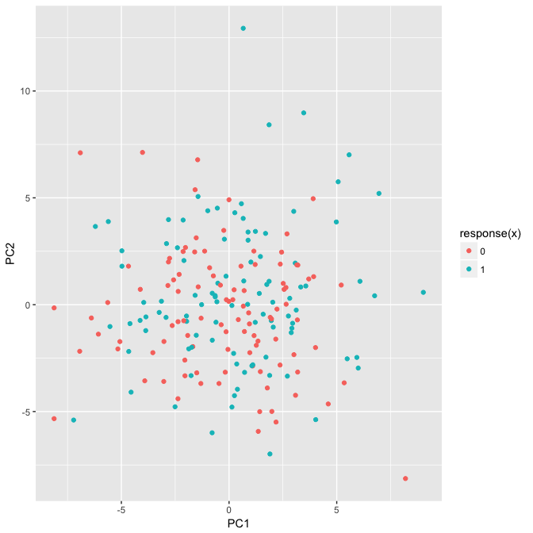

```r
plotMDT(mdt,
        type = "scatter",
        preprocess = c("scale", "center", "pca"),
        space = c("samples"),
        dims = c(1L, 2L))
```

Here under is a heatmap plot of associated SNPs. As you can see, there is a good separation between cases (blue) and controls (red).

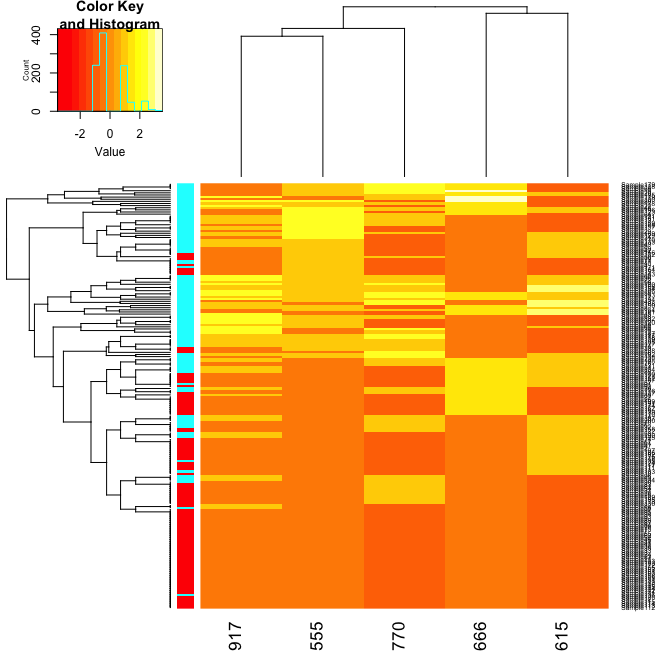

```r
try(plotMDT(filterMDT(mdt, INFO_AS == 1, "info"),
        type = "heatmap",
        preprocess = c("scale", "center")))
```

Finally, it is possible to create Manhattan plots using any numeric value in `annotations`. Here, we will illustrate this using results from Fisher’s exact test we have computed using `annotateStat`

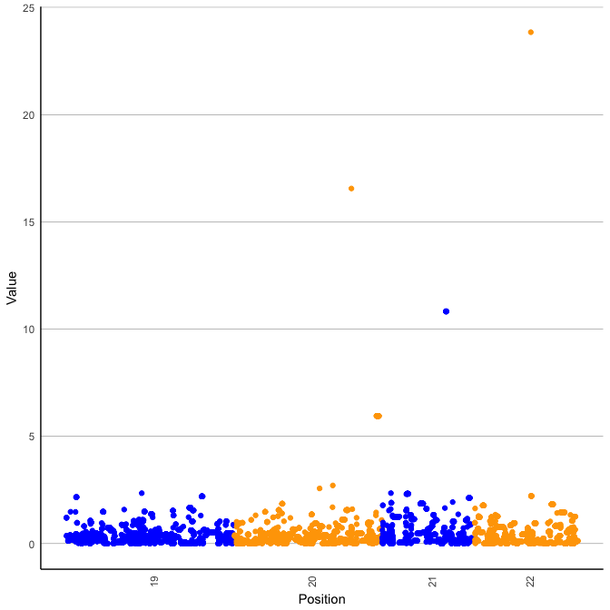

```r
manhattanPlot(mdt, "FISHER")
```

## 6. MLGWAS Objects - Training Classifiers

`MDT` objects can be used to train classifiers; results are contained in `MLGWAS` objects. This is possible using `trainClassifier`.

This function can be thought of as a wrapper for the `train` function in the `caret` package. By default, the function is composed of two main loops corresponding to double fold cross-validation. The outer fold is specified by the `partitions` argument, a `list` of indices which define the training set. The training set is used for preprocessing (a `function` specified by the `preprocess` argument) and as input for `train`. The test set is all other indices; it is neither used preprocessing, training and will be used to estimate performance measures. It is, however, possible to set the test set as the whole dataset by setting `validation` to `FALSE`. The inner fold is handled by `train` and can be set using its `trControl` and `tuneGrid` argument. Actually, any argument can be passed on to `train`.

```r
allfeat <- MachineLearningGWAS::features(mdt)
associated <- unique(MachineLearningGWAS::info(mdt)[INFO_AS == 1, FeatureID])
random <- sample(allfeat[! allfeat %in% associated], 15)
selected <- c(associated, random)
mdt <- mdt[, selected]

clas <- trainClassifier(mdt, id = "clas", phen_vars = "all", method = 'rf')
```

An `MLGWAS` object is composed of three main `data.table`: `performances`, `featimp`, `errors`. These are interlinked by fours identifiers (i.e. keys). `SampleID` and `FeatureID` are extracted from the `MDT` objects. `ClassifierID` is determined by the `id` argument when calling `trainClassifier`. Finally, `PartitionID` is determined by the names of the `partition` argument. Printing the `MLGWAS` object reveals its identifiers. It should be noted that each of these `data.table` as an associated `summary` and `plot` function.

```r
clas
```

```
--- MLGWAS object ---
1 classifiers: clas
10 partitions: Fold01.Rep1, Fold02.Rep1, Fold03.Rep1, Fold04.Rep1, Fold05.Rep1, ...
22 features: 105, 114, 135, 18, 30, ...
200 samples: Sample1, Sample10, Sample100, Sample101, Sample102, ...
```

`performances` contains estimates about classifier performance across different folds (partitions). It can be summarized using `summaryPerf`

```r
performances(clas)
```

```
    ClassifierID PartitionID  Accuracy    ROCAUC       PPV       NPV
 1:         clas Fold01.Rep1 0.8947368 0.8888889 0.8333333 1.0000000
 2:         clas Fold02.Rep1 0.8500000 0.8500000 0.8181818 0.8888889
 3:         clas Fold03.Rep1 1.0000000 1.0000000 1.0000000 1.0000000
 4:         clas Fold04.Rep1 0.9523810 0.9545455 1.0000000 0.9090909
 5:         clas Fold05.Rep1 1.0000000 1.0000000 1.0000000 1.0000000
 6:         clas Fold06.Rep1 0.9500000 0.9500000 0.9090909 1.0000000
 7:         clas Fold07.Rep1 0.9500000 0.9500000 1.0000000 0.9090909
 8:         clas Fold08.Rep1 0.9500000 0.9500000 0.9090909 1.0000000
 9:         clas Fold09.Rep1 0.9000000 0.9000000 0.9000000 0.9000000
10:         clas Fold10.Rep1 0.9000000 0.9000000 1.0000000 0.8333333
    Sensitivity Specificity   F1Score
 1:   1.0000000   0.7777778 0.9090909
 2:   0.9000000   0.8000000 0.8571429
 3:   1.0000000   1.0000000 1.0000000
 4:   0.9090909   1.0000000 0.9523810
 5:   1.0000000   1.0000000 1.0000000
 6:   1.0000000   0.9000000 0.9523810
 7:   0.9000000   1.0000000 0.9473684
 8:   1.0000000   0.9000000 0.9523810
 9:   0.9000000   0.9000000 0.9000000
10:   0.8000000   1.0000000 0.8888889
```

```r
summaryPerf(clas)
```

```
   ClassifierID Summary    Accuracy      ROCAUC         PPV         NPV
1:         clas    mean  0.93471178  0.93434343  0.93696970  0.94404040
2:         clas      sd  0.04798424  0.04865291  0.07275252  0.06266101
3:         clas     len 10.00000000 10.00000000 10.00000000 10.00000000
   Sensitivity Specificity    F1Score
1:  0.94090909  0.92777778  0.9359634
2:  0.06939989  0.08642416  0.0466479
3: 10.00000000 10.00000000 10.0000000
```

`featimp` contains feature importance across folds. These values are obtained calling `varImp` for `caret`. It can be summarized using `summaryFeatimp`

```r
head(featimp(clas))
```

```
   ClassifierID PartitionID FeatureID  Importance
1:         clas Fold01.Rep1       105 6.581981806
2:         clas Fold01.Rep1       114 0.008179545
3:         clas Fold01.Rep1       135 1.949714639
4:         clas Fold01.Rep1        18 9.055058882
5:         clas Fold01.Rep1        30 4.795876359
6:         clas Fold01.Rep1       350 7.684334815
```

```r
head(summaryFeatimp(clas))
```

```
   ClassifierID FeatureID      mean        sd len
1:         clas       105 5.3855108 0.7992505  10
2:         clas       114 0.0679622 0.1305055  10
3:         clas       135 1.6748299 0.7568015  10
4:         clas        18 7.9673276 0.7320299  10
5:         clas        30 5.5747477 0.4263509  10
6:         clas       350 7.6375052 0.4464784  10
```

Finally, `errors` represent local residuals. It can help identify samples that are too predict. For categorical responses, `0` represents a success and `1` an error. It can be summarized using `summaryErrors`

```r
head(na.omit(errors(clas)))
```

```
   ClassifierID  SampleID PartitionID Error
1:         clas   Sample1 Fold02.Rep1     0
2:         clas  Sample10 Fold06.Rep1     0
3:         clas Sample100 Fold03.Rep1     0
4:         clas Sample101 Fold01.Rep1     0
5:         clas Sample102 Fold01.Rep1     0
6:         clas Sample103 Fold10.Rep1     0
```

```r
head(summaryErrors(clas))
```

```
   ClassifierID  SampleID mean sd len
1:         clas   Sample1    0 NA   1
2:         clas  Sample10    0 NA   1
3:         clas Sample100    0 NA   1
4:         clas Sample101    0 NA   1
5:         clas Sample102    0 NA   1
6:         clas Sample103    0 NA   1
```

One may with to compare performance results with a random setting. This can be done using permutations. We then bind the two objects together using `bindML`.

```r
perm <- trainClassifier(mdt, id = "perm",
                        method = 'rf', phen_vars = "all",
                        permute = TRUE)
fits <- bindML(clas, perm)
```

There exists different three main functions to plot `MLGWAS` objects: `plotPerf`, `plotFeatimp` and `plotErrors`.

`plotPerf` plots performance measures. Here under we plot accuracy values. As expected, the classifier using the unpermuted data (`clas`) outperforms random predictions (`perm`).

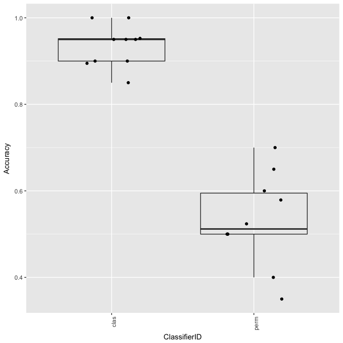

```r
plotPerf(fits, "Accuracy")
```

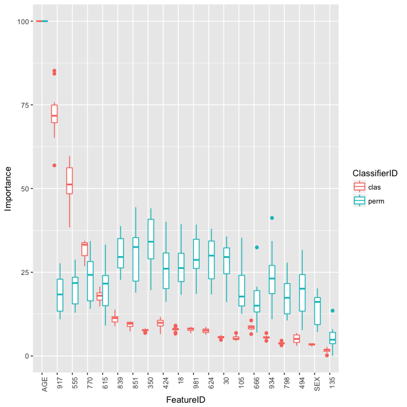

```r
plotFeatimp(fits)
```

Finally, it possible to look at residual errors (i.e. per sample error) using `plotErrors`.

It is also possible to create different types of models by playing around with arguments. One should also not that any argument in `train` can be passed on. For example, we can do 10 bootstraps instead of double fold cross validation with the following code.

```r
ml <- trainClassifier(mdt, id = "boot",
                      partition = caret::createResample(response(mdt),
                                                        times = 10),
                      trControl = trainControl("none"),
                      tuneGrid = data.frame(.mtry = 5L),
                      validation = FALSE)
```

It also possible to create a preprocessing function that only selects the 5 most associated values as determined by Fisher’s exact test as follows. This can then be used as input to the `preprocess` argument.

```r
fisherSelector <- function(x, y) {
  pv <- apply(x, 2, function(col) {
    fisher.test(table(factor(col, 0:2), y))$p.value
  })
  pv <- sort(pv)
  selected <- names(pv)[1:5]
  function(x) x[, selected]
}
```

Finally, the `trainClassifiers` function allow to call `trainClassifier` iteratively using a `data.frame` of parameters. For example, instead of calling two times `trainClassifer` to get a real and a permuted classifier, one can run this code. Note: functions must be defined within a `vector`.

```r
params <- expand.grid(method = "rf",
                      permuted = c(TRUE, FALSE),
                      preprocess = c(fisherSelector))
params$id <- c("perm", "real")
fits2 <- trainClassifiers(mdt, params)
```